# Excercise 4 - Clustering and classification

## Introduction and data

We use the built-in R `Boston` data set which explores housing values in suburbs of Boston.

```r
# load the library MASS, and the data.
library(MASS)
data(Boston)

str(Boston)
```

```
## 'data.frame':    506 obs. of  14 variables:
##  $ crim   : num  0.00632 0.02731 0.02729 0.03237 0.06905 ...
##  $ zn     : num  18 0 0 0 0 0 12.5 12.5 12.5 12.5 ...
##  $ indus  : num  2.31 7.07 7.07 2.18 2.18 2.18 7.87 7.87 7.87 7.87 ...
##  $ chas   : int  0 0 0 0 0 0 0 0 0 0 ...
##  $ nox    : num  0.538 0.469 0.469 0.458 0.458 0.458 0.524 0.524 0.524 0.524 ...
##  $ rm     : num  6.58 6.42 7.18 7 7.15 ...
##  $ age    : num  65.2 78.9 61.1 45.8 54.2 58.7 66.6 96.1 100 85.9 ...
##  $ dis    : num  4.09 4.97 4.97 6.06 6.06 ...
##  $ rad    : int  1 2 2 3 3 3 5 5 5 5 ...
##  $ tax    : num  296 242 242 222 222 222 311 311 311 311 ...
##  $ ptratio: num  15.3 17.8 17.8 18.7 18.7 18.7 15.2 15.2 15.2 15.2 ...
##  $ black  : num  397 397 393 395 397 ...
##  $ lstat  : num  4.98 9.14 4.03 2.94 5.33 ...
##  $ medv   : num  24 21.6 34.7 33.4 36.2 28.7 22.9 27.1 16.5 18.9 ...
```

```r
dim(Boston)
```

```
## [1] 506  14
```

An explanation of the 14 variables can be found [here.](https://stat.ethz.ch/R-manual/R-devel/library/MASS/html/Boston.html) 12 are numeric, `chas` is a binary masked as an integer (0 or 1) and `rad` is an index in integer form (1 to 24). There are 506 observations of each variable.

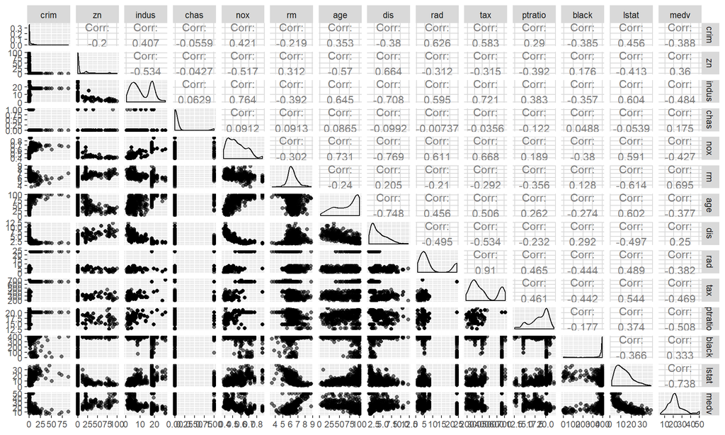

```r
par <- ggpairs(Boston, mapping = aes(alpha = 0.3), lower = list(combo = wrap("facethist", bins = 20)))
par
```

The `ggpairs()` plot contains a lot of information, and is a bit crowded with so many variables althoug you can see some patterns appearing with regards to correlation. Most variables do not seem to be normally distributed. Lets have a look at a colored correlation plot.

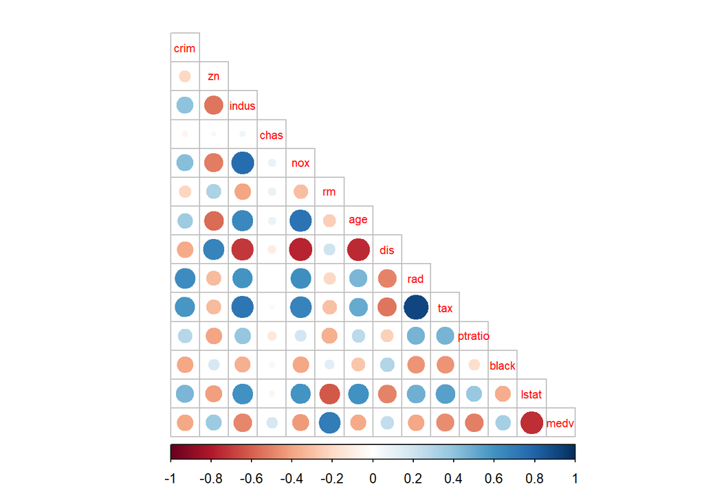

```r
# assign correlation matrix
cor_mtrx <- cor(Boston)
# plot
corrplot(cor_mtrx, method="circle", type="lower", cl.pos="b", tl.pos="d", tl.cex=0.7)
```

This nicely shows correlation between variables. To name a few: `indus` (proportion of land in use of industry) and `nox` (concentration of nitrogen oxides) are positively correlated, and negatively correlated with `dis` (distance to highways). This seems reasonable.

## We´ll standardise the data

```r
# center and standardize variables
boston_scaled <- scale(Boston, center=T, scale=T)

# change matrix to data frame
boston_scaled <- as.data.frame(boston_scaled)

# summaries of the scaled variables
summary(boston_scaled)
```

```
##       crim                 zn               indus
##  Min.   :-0.419367   Min.   :-0.48724   Min.   :-1.5563
##  1st Qu.:-0.410563   1st Qu.:-0.48724   1st Qu.:-0.8668
##  Median :-0.390280   Median :-0.48724   Median :-0.2109
##  Mean   : 0.000000   Mean   : 0.00000   Mean   : 0.0000
##  3rd Qu.: 0.007389   3rd Qu.: 0.04872   3rd Qu.: 1.0150
##  Max.   : 9.924110   Max.   : 3.80047   Max.   : 2.4202
##       chas              nox                rm               age
##  Min.   :-0.2723   Min.   :-1.4644   Min.   :-3.8764   Min.   :-2.3331
##  1st Qu.:-0.2723   1st Qu.:-0.9121   1st Qu.:-0.5681   1st Qu.:-0.8366
##  Median :-0.2723   Median :-0.1441   Median :-0.1084   Median : 0.3171
##  Mean   : 0.0000   Mean   : 0.0000   Mean   : 0.0000   Mean   : 0.0000
##  3rd Qu.:-0.2723   3rd Qu.: 0.5981   3rd Qu.: 0.4823   3rd Qu.: 0.9059
##  Max.   : 3.6648   Max.   : 2.7296   Max.   : 3.5515   Max.   : 1.1164
##       dis               rad               tax             ptratio
##  Min.   :-1.2658   Min.   :-0.9819   Min.   :-1.3127   Min.   :-2.7047
##  1st Qu.:-0.8049   1st Qu.:-0.6373   1st Qu.:-0.7668   1st Qu.:-0.4876
##  Median :-0.2790   Median :-0.5225   Median :-0.4642   Median : 0.2746
##  Mean   : 0.0000   Mean   : 0.0000   Mean   : 0.0000   Mean   : 0.0000
##  3rd Qu.: 0.6617   3rd Qu.: 1.6596   3rd Qu.: 1.5294   3rd Qu.: 0.8058
##  Max.   : 3.9566   Max.   : 1.6596   Max.   : 1.7964   Max.   : 1.6372
##      black             lstat              medv
##  Min.   :-3.9033   Min.   :-1.5296   Min.   :-1.9063
##  1st Qu.: 0.2049   1st Qu.:-0.7986   1st Qu.:-0.5989
##  Median : 0.3808   Median :-0.1811   Median :-0.1449
##  Mean   : 0.0000   Mean   : 0.0000   Mean   : 0.0000
##  3rd Qu.: 0.4332   3rd Qu.: 0.6024   3rd Qu.: 0.2683
##  Max.   : 0.4406   Max.   : 3.5453   Max.   : 2.9865
```

With ´scale()` on default settings we center the data on 0, and divide each variable by its standard deviation, effectively making the SD = 1 for each variable. We do this due to the requirements of *Linear discriminant analysis*.

## Some data wrangling

Now we create a categorical variable for crime rate from the quantiles of `crim`. Also we divide the data into a `train` and `test` set with 80% of data in the train set. Well remove the correct `crime` classes from the test set after saving them separately as `true_crime`.

```r
# create a quantile vector of crim
bins <- quantile(boston_scaled$crim)

# create a categorical variable 'crime' with the quantiles.
lblz <- c("low", "med_low", "med_high","high")
crime <- cut(boston_scaled$crim, breaks = bins, labels = lblz, include.lowest = TRUE)

# remove original crim from the dataset
boston_scaled <- dplyr::select(boston_scaled, -crim)

# add the new categorical value to scaled data
boston_scaled <- data.frame(boston_scaled, crime)

# randomly choose 80% of rows, yields 404 rows.
selection <- sample(nrow(boston_scaled), size = 0.8*nrow(boston_scaled))

#gen train set
train <- boston_scaled[selection,]

#gen test set
test <- boston_scaled[-selection,]

# remove correct classes from test set.
true_crime <- test$crime
test <- dplyr::select(test, -crime)
```

## After this data wrangling we are ready for linear discriminant analysis with `crime` as target variable, and all others as predictors.

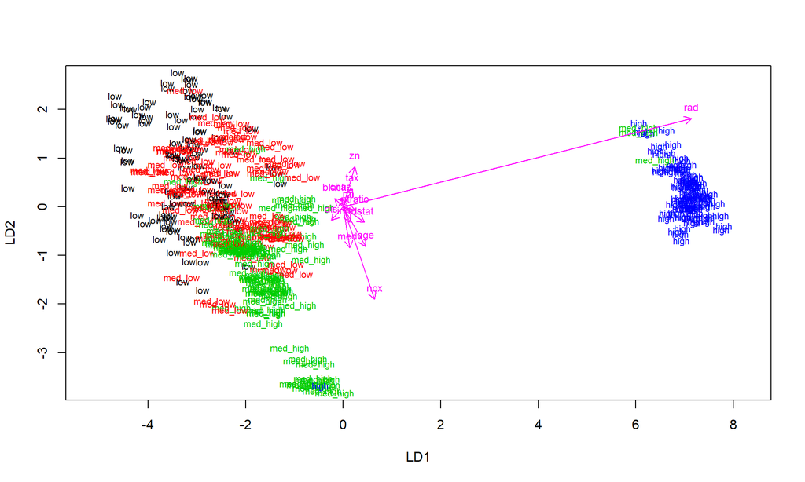

```r
#we fit the modelwith crime
lda.fit <- lda(crime ~ ., data = train)

# we define a function for producing arrows in the plot
lda.arrows <- function(x, myscale = 1, arrow_heads = 0.1, color = "magenta", tex = 0.75, choices = c(1,2)){
  heads <- coef(x)
  arrows(x0 = 0, y0 = 0,
         x1 = myscale * heads[,choices[1]],
         y1 = myscale * heads[,choices[2]], col=color, length = arrow_heads)
  text(myscale * heads[,choices], labels = row.names(heads),
       cex = tex, col=color, pos=3)
}

#
crime_classes <- as.numeric(train$crime) #for colors in plot
plot(lda.fit, col = crime_classes, pch = crime_classes, dimen =2)
lda.arrows(lda.fit, myscale =2)
```

```r
#plot(boston_scaled$crime, boston_scaled$rad)
```

## We´ll predict classes in the test dataset.

```r
# did the removing of crime from test set already in the chunk "categorize crime"
# predict classes with test data
lda.pred <- predict(lda.fit, newdata = test)

# cross tabulate the results
table(correct = true_crime, predicted = lda.pred$class)
```

```
##           predicted
## correct    low med_low med_high high
##   low       10       6        3    0
##   med_low    5      11       10    0
##   med_high   0      14       13    3
##   high       0       0        0   27
```

The model is able to predict crime rate class pretty well. It has most trouble separating `med_low` from its neighbors.

## And now for some distance measures

We´ll count euclidean distances for the standardised and centered Boston dataset and view a summary of distances. Then well run kmeans on the data with 4 clusters, and have a look at an example plot with some of the variables.

```r
data(Boston)
centbost <- scale(Boston, center=T, scale=T)
dist_eu <- dist(centbost)
summary(dist_eu)
```

```
##    Min. 1st Qu.  Median    Mean 3rd Qu.    Max.
##  0.1343  3.4625  4.8241  4.9111  6.1863 14.3970
```

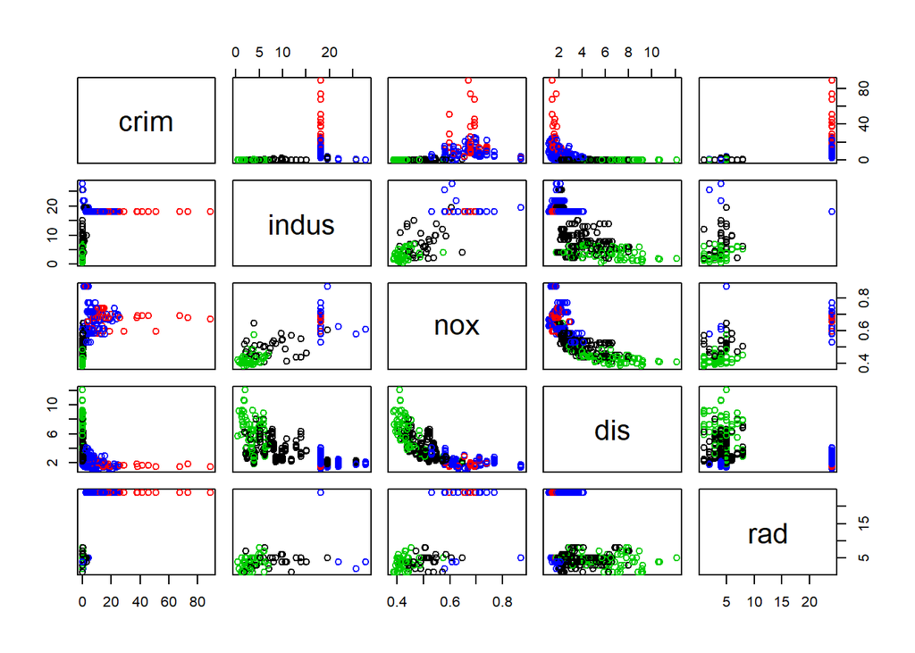

```r
#run kmeans
km <- kmeans(centbost, centers = 4)

#plot
pairs(Boston[c(1,3,5,8,9)], col = km$cluster)
```

We´ll calculate the otpimum number of clusters by looking at within cluster sum of squares based on how many clusters we use. We plot wcss by number of clusters, and the optimum number of clusters should be where wcss drops radically.

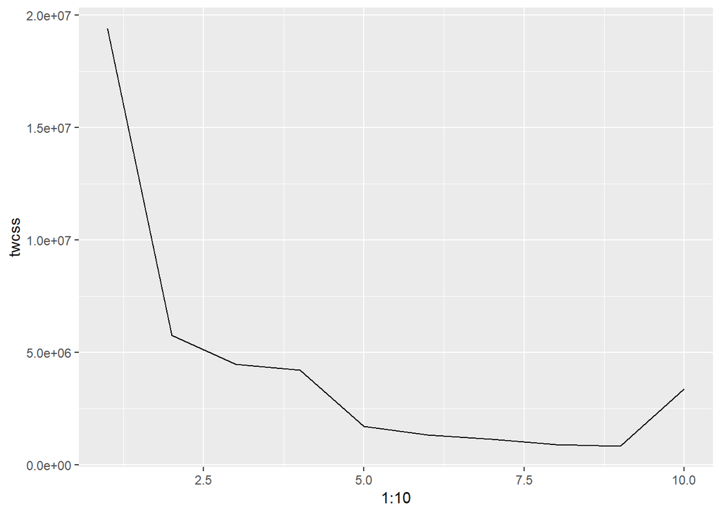

```r
# calculate the total within sum of squares
twcss <- sapply(1:10, function(k){kmeans(Boston, k)$tot.withinss})

# visualize the results
qplot(x = 1:10, y = twcss, geom = 'line')
```

Two in this case. Well run the kmeans with 2 centers, and plot the pairs in Boston coloring by these centers.

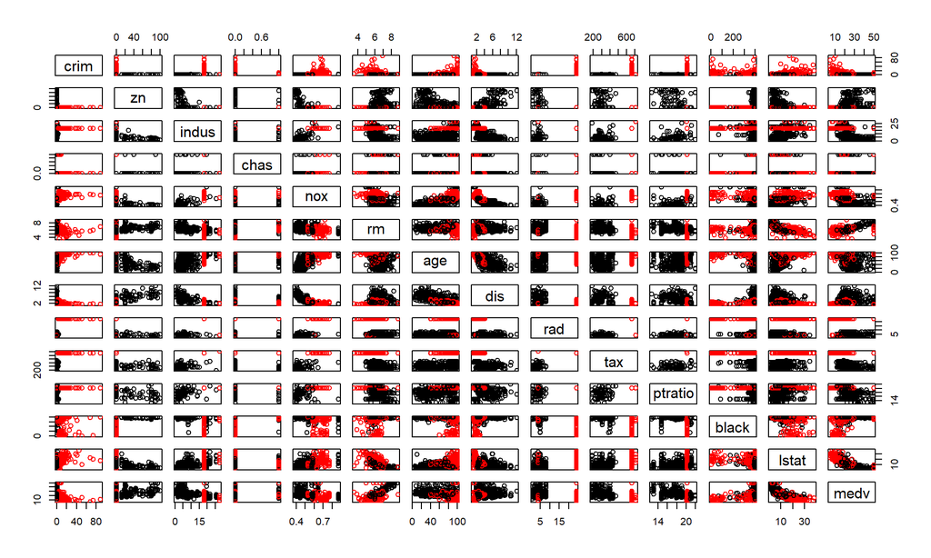

```r
# k-means clustering
km2 <-kmeans(Boston, centers = 2)

# plot the Boston dataset with clusters
pairs(Boston, col = km2$cluster)
```

## Let´s try the Bonus excercise:

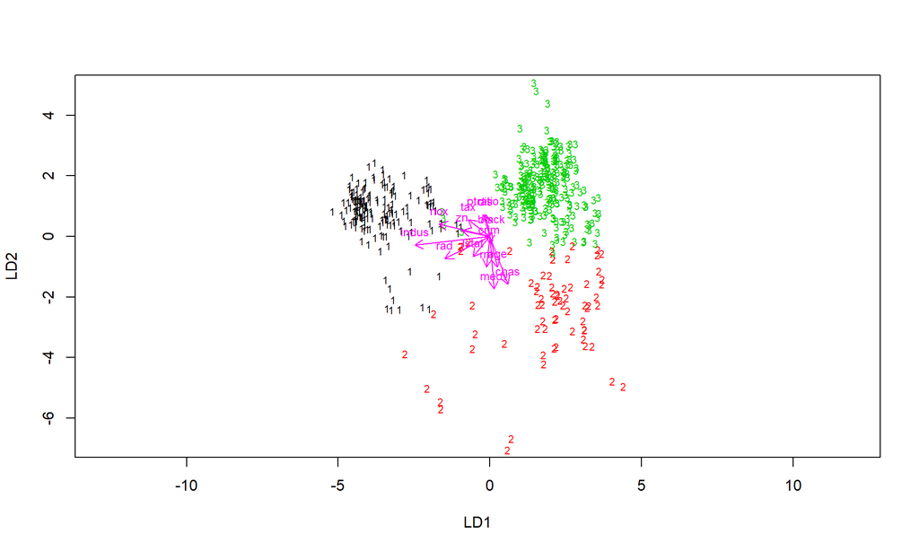

```r
data(Boston)
BBoston <- as.data.frame(scale(Boston, center=T, scale=T)) # center and scale, as data frame


#run kmeans
kmB <- kmeans(BBoston, centers = 3)

#we fit the modelwith crime
lda.fit <- lda(kmB$cluster ~ ., data = BBoston)

# we define a function for producing arrows in the plot
lda.arrows <- function(x, myscale = 1, arrow_heads = 0.1, color = "magenta", tex = 0.75, choices = c(1,2)){
  heads <- coef(x)
  arrows(x0 = 0, y0 = 0,
         x1 = myscale * heads[,choices[1]],
         y1 = myscale * heads[,choices[2]], col=color, length = arrow_heads)
  text(myscale * heads[,choices], labels = row.names(heads),
       cex = tex, col=color, pos=3)
}

#
# crime_classes <- as.numeric(train$crime) #for colors in plot
plot(lda.fit, col = kmB$cluster, dimen =2)
lda.arrows(lda.fit, myscale =2)
```